# Predicting Insurance Premiums

Author

Liam A. Doyle

# Introduction

This project involves the prediction of insurance premiums using several machine learning models. The primary objective of the project was to generate a model that outperformed a null model (i.e., the mean) in predicting `premium_amount`.

## Dataset

The dataset includes both continuous (e.g., `annual_income`) and categorical (e.g., `gender`) features in order to predict a continuous outcome (i.e., `premium_amount`). This dataset was retrieved from [Kaggle](https://www.kaggle.com/competitions/playground-series-s4e12/overview). In order to keep the dataset manageable for my computing resources, a random sample of 5,000 observations was drawn from the total dataset (1,200,000 observations).

# Importing Packages

The following packages were used for this project:

- `tidyverse`
- `janitor`
- `DT`
- `skimr`
- `lubridate`
- `tidymodels`
- `glmnet`
- `ranger`
- `xgboost`
- `doParallel`
- `finetune`
- `DALEXtra`

```r
library(tidyverse) # for data manipulation
library(janitor) # for cleaning column names
library(DT) # for viewing data interactively
library(skimr) # for generating summary statistics
library(lubridate) # for working with date-time data
library(tidymodels) # for data pre-processing, feature engineering, and modelling
library(glmnet) # for elastic net regression
library(ranger) # for random forest models
library(xgboost) # for eXtreme gradient boosting model
library(doParallel) # for parallel processing
library(finetune) # for grid searching via racing method
library(DALEXtra) # for feature importance

options (scipen = 999) # disable scientific notation
```

# Importing Data

```r
set.seed(123) # setting seed for reproducibility

train <- read_csv("train.csv")
data <- train %>%
  slice_sample(n = 5000) %>% # randomly sampling 5000 observations
  clean_names() %>% # using janitor to convert names to snakecase
  mutate(across(where(is.character), ~as.factor(.x))) # changing character columns to factors

datatable(head(data, 10)) # using datatable to view the data structure
```

|  | id | age | gender | annual_income | marital_status | number_of_dependents | education_level | occupation | health_score | location | policy_type | previous_claims | vehicle_age | credit_score | insurance_duration | policy_start_date | customer_feedback | smoking_status | exercise_frequency | property_type | premium_amount |
| --- | --- | --- | --- | --- | --- | --- | --- | --- | --- | --- | --- | --- | --- | --- | --- | --- | --- | --- | --- | --- | --- |
| 1 | 134057 | 61 | Male | 44270 | Divorced | 0 | High School | Self-Employed | 17.62442805185713 | Rural | Premium |  | 0 | 399 | 7 | 2022-02-23T15:21:39Z | Good | Yes | Weekly | Apartment | 1124 |
| 2 | 1172597 | 52 | Male | 39658 | Married | 2 | Master's | Unemployed | 29.51291777537287 | Urban | Basic |  | 7 | 644 | 1 | 2020-07-27T15:21:39Z | Good | Yes | Weekly | House | 748 |
| 3 | 685284 | 58 | Male | 6524 | Divorced | 3 | Master's | Employed | 32.37780158238548 | Urban | Comprehensive | 1 | 16 | 745 | 2 | 2022-05-07T15:21:39Z | Poor | No | Daily | Apartment | 2066 |
| 4 | 497689 | 29 | Male | 45754 | Married | 1 | High School |  | 35.61938993229942 | Rural | Comprehensive |  | 3 | 558 | 5 | 2021-07-15T15:21:39Z | Average | No | Monthly | Condo | 901 |
| 5 | 402857 | 61 | Male | 23685 | Married | 2 | Master's | Self-Employed | 9.849791547257269 | Suburban | Premium |  | 12 | 739 | 6 | 2020-07-11T15:21:39Z | Poor | Yes | Rarely | Apartment | 954 |
| 6 | 583421 | 20 | Female |  | Divorced | 3 | High School |  | 10.87924018715526 | Urban | Basic | 1 | 10 | 464 | 7 | 2020-07-07T15:21:39Z |  | No | Daily | House | 1827 |
| 7 | 883280 | 35 | Female | 38925 | Married | 0 | High School | Employed | 13.02781856629277 | Urban | Basic |  | 0 | 805 | 2 | 2024-05-31T15:21:39Z | Good | Yes | Weekly | House | 735 |
| 8 | 669542 | 23 | Male | 41534 | Married |  | Bachelor's | Self-Employed | 46.93907899057056 | Rural | Basic | 0 | 4 | 419 | 7 | 2023-08-01T15:21:39Z | Good | Yes | Daily | Condo | 3206 |
| 9 | 944671 | 37 | Female | 13336 | Married | 4 | High School | Employed | 17.29362999391986 | Suburban | Premium | 0 | 17 |  | 7 | 2020-09-29T15:21:39Z | Good | Yes | Rarely | Apartment | 690 |
| 10 | 613996 | 34 | Male | 8054 | Married | 3 | PhD | Employed | 14.92657691664883 | Suburban | Comprehensive | 1 | 11 |  | 5 | 2021-07-06T15:21:39Z | Good | Yes | Daily | Apartment | 1240 |

# Splitting Data

Prior to splitting the data, the outcome variable (`premium_amount`) was visualized using a histogram to ensure that simple random sampling would be appropriate.

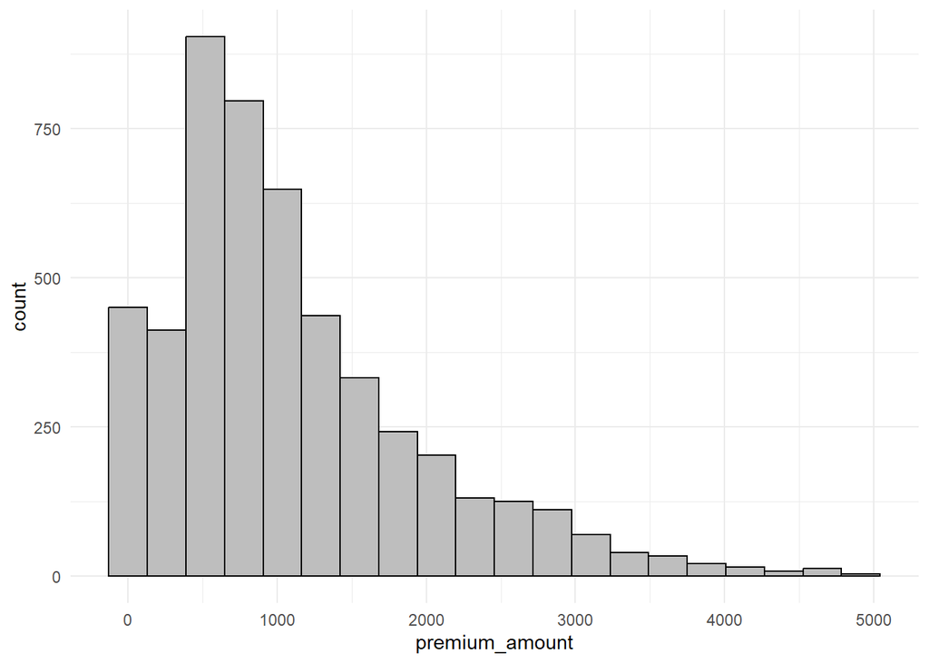

```r
ggplot(data, aes(x = premium_amount)) +
  geom_histogram(bins = 20, fill = "grey", color = "black") +
  theme_minimal()
```

The data was split into a training and testing set using `rsample`. A 75/25 division was used. Given the fact that the distribution of `premium_amount` was right-skewed, stratified random sampling was used to ensure that the distribution was preserved.

```r
set.seed(123)

data_split <- initial_split(data, strata = premium_amount) # creating rsplit object

train <- training(data_split) # extracting dfs for training and testing data
test <- testing(data_split)
```

# Exploratory Data Analysis

## Summary Statistics

To familiarize myself with the data, common summary statistics were generated using `skimr`.

```r
skim(train) # examining summary statistics for data using `skimr`
```

Data summary

| Name | train |
| --- | --- |
| Number of rows | 3748 |
| Number of columns | 21 |
| _______________________ |  |
| Column type frequency: |  |
| factor | 10 |
| numeric | 10 |
| POSIXct | 1 |
| ________________________ |  |
| Group variables | None |

**Variable type: factor**

| skim_variable | n_missing | complete_rate | ordered | n_unique | top_counts |
| --- | --- | --- | --- | --- | --- |
| gender | 0 | 1.00 | FALSE | 2 | Mal: 1904, Fem: 1844 |
| marital_status | 54 | 0.99 | FALSE | 3 | Sin: 1273, Mar: 1222, Div: 1199 |
| education_level | 0 | 1.00 | FALSE | 4 | Mas: 991, PhD: 963, Bac: 954, Hig: 840 |
| occupation | 1138 | 0.70 | FALSE | 3 | Sel: 886, Une: 871, Emp: 853 |
| location | 0 | 1.00 | FALSE | 3 | Sub: 1271, Rur: 1254, Urb: 1223 |
| policy_type | 0 | 1.00 | FALSE | 3 | Pre: 1252, Com: 1250, Bas: 1246 |
| customer_feedback | 227 | 0.94 | FALSE | 3 | Goo: 1177, Poo: 1174, Ave: 1170 |
| smoking_status | 0 | 1.00 | FALSE | 2 | Yes: 1918, No: 1830 |
| exercise_frequency | 0 | 1.00 | FALSE | 4 | Wee: 971, Rar: 962, Dai: 943, Mon: 872 |
| property_type | 0 | 1.00 | FALSE | 3 | Hou: 1292, Apa: 1245, Con: 1211 |

**Variable type: numeric**

| skim_variable | n_missing | complete_rate | mean | sd | p0 | p25 | p50 | p75 | p100 | hist |
| --- | --- | --- | --- | --- | --- | --- | --- | --- | --- | --- |
| id | 0 | 1.00 | 603137.32 | 346814.40 | 37.00 | 308779.75 | 599790.00 | 908534.50 | 1199879.00 | ▇▇▇▇▇ |
| age | 72 | 0.98 | 41.06 | 13.66 | 18.00 | 29.00 | 41.00 | 53.00 | 64.00 | ▇▇▇▇▇ |
| annual_income | 155 | 0.96 | 31802.98 | 31521.83 | 17.00 | 7481.00 | 23595.00 | 43841.00 | 149521.00 | ▇▃▁▁▁ |
| number_of_dependents | 353 | 0.91 | 2.00 | 1.41 | 0.00 | 1.00 | 2.00 | 3.00 | 4.00 | ▇▇▇▇▇ |
| health_score | 230 | 0.94 | 25.43 | 12.07 | 2.16 | 15.78 | 24.24 | 34.46 | 53.94 | ▅▇▇▅▂ |
| previous_claims | 1140 | 0.70 | 1.03 | 1.00 | 0.00 | 0.00 | 1.00 | 2.00 | 5.00 | ▇▂▁▁▁ |
| vehicle_age | 0 | 1.00 | 9.52 | 5.75 | 0.00 | 5.00 | 10.00 | 14.00 | 19.00 | ▇▇▇▇▇ |
| credit_score | 438 | 0.88 | 592.64 | 150.52 | 300.00 | 466.00 | 592.50 | 721.50 | 849.00 | ▅▇▇▇▇ |
| insurance_duration | 0 | 1.00 | 5.04 | 2.58 | 1.00 | 3.00 | 5.00 | 7.00 | 9.00 | ▇▇▃▇▇ |
| premium_amount | 0 | 1.00 | 1099.98 | 864.91 | 20.00 | 517.00 | 881.00 | 1488.75 | 4850.00 | ▇▅▂▁▁ |

**Variable type: POSIXct**

| skim_variable | n_missing | complete_rate | min | max | median | n_unique |
| --- | --- | --- | --- | --- | --- | --- |
| policy_start_date | 0 | 1 | 2019-08-17 15:21:39 | 2024-08-15 15:21:39 | 2022-02-25 03:21:39 | 3642 |

## Correlations

A correlation matrix was generated to examine the correlations between the numeric variables in the dataset. This was done to better understand the data and determine if any features were highly associated with one another.

```r
train_numeric <- train %>%
  select(where(is.numeric), -id) # select numeric variables

cor_matrix <- round(cor(train_numeric, use = "pairwise.complete.obs"), 3)

upper<-cor_matrix
upper[upper.tri(cor_matrix)] <- ""
upper <- as.data.frame(upper) # create APA-style correlation matrix

datatable(upper)
```

|  | age | annual_income | number_of_dependents | health_score | previous_claims | vehicle_age | credit_score | insurance_duration | premium_amount |
| --- | --- | --- | --- | --- | --- | --- | --- | --- | --- |
| age | 1 |  |  |  |  |  |  |  |  |
| annual_income | -0.015 | 1 |  |  |  |  |  |  |  |
| number_of_dependents | -0.041 | 0.009 | 1 |  |  |  |  |  |  |
| health_score | -0.019 | 0.03 | 0.017 | 1 |  |  |  |  |  |
| previous_claims | 0.015 | 0.034 | -0.01 | 0.008 | 1 |  |  |  |  |
| vehicle_age | -0.039 | 0.037 | 0.006 | 0.031 | 0.032 | 1 |  |  |  |
| credit_score | -0.01 | -0.178 | -0.006 | 0.018 | 0.06 | -0.027 | 1 |  |  |
| insurance_duration | -0.011 | 0.029 | -0.031 | -0.022 | -0.005 | 0.005 | -0.005 | 1 |  |
| premium_amount | 0.01 | -0.024 | -0.007 | 0.036 | 0.058 | -0.008 | -0.019 | -0.026 | 1 |

## Visualizations

### Histograms of Continuous Variables

A series of histograms were generated to understand the distribution of the continuous variables in the dataset.

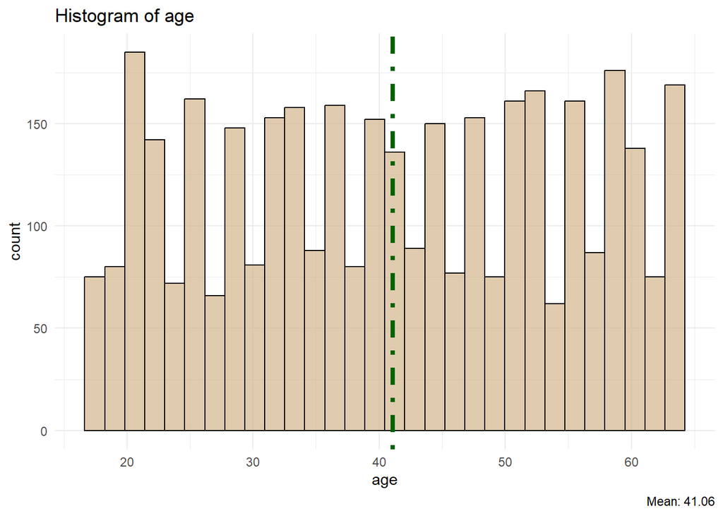

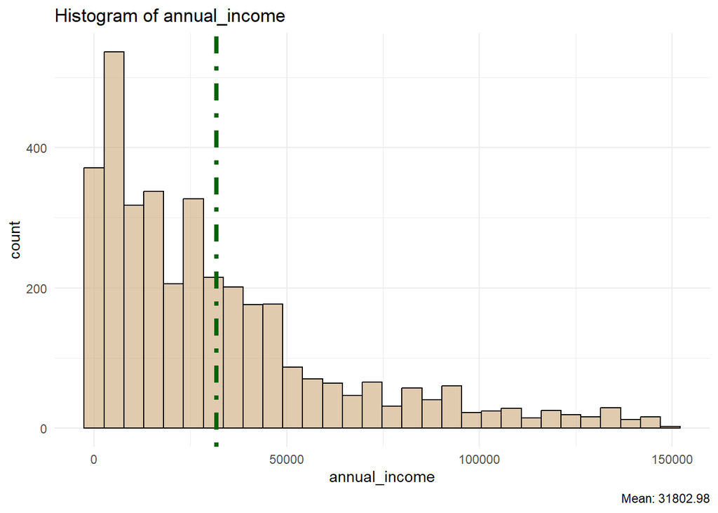

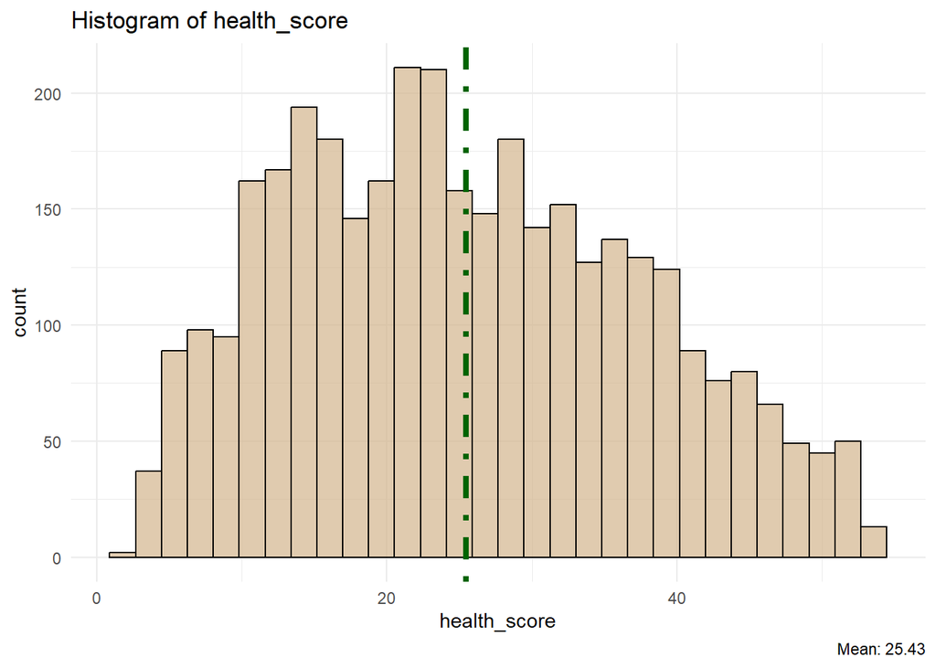

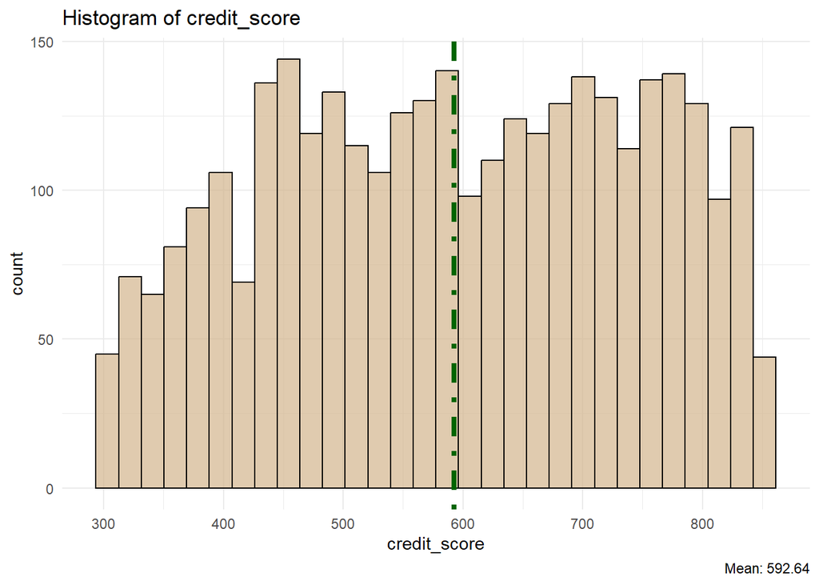

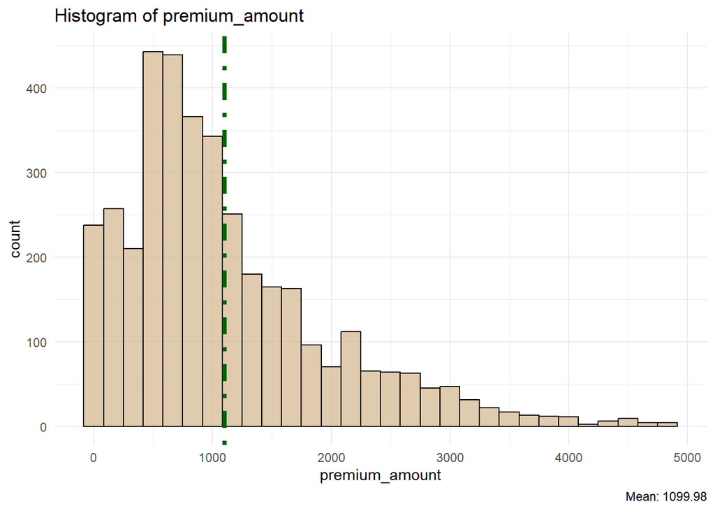

```r
continuous_vars <- c(
  "age",
  "annual_income",
  "health_score",
  "credit_score",
  "premium_amount"
)

continuous_histograms <- lapply(continuous_vars, function(var) {
  ggplot(train, aes(x = !!sym(var))) +
    geom_histogram(fill = "tan",
                   color = "black",
                   alpha = 0.7) +
    geom_vline(aes(xintercept = mean(!!sym(var), na.rm = TRUE)),
               linewidth = 1.5,
               linetype = "dotdash",
               color = "darkgreen") +
    theme_minimal() +
    labs(
      title = paste("Histogram of", var),
      caption = str_c("Mean: ", round(mean(train[[var]], na.rm = TRUE), 2))
    )
})

print(continuous_histograms)
```

### Box Plots of Continuous Variables

Similarly, a series of box plots were generated to visualize key aspects of the distribution of the continuous variables.

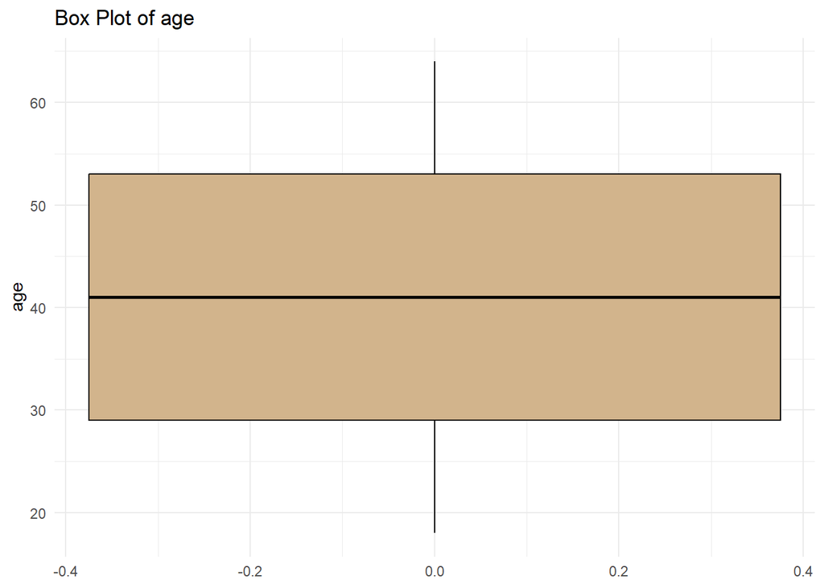

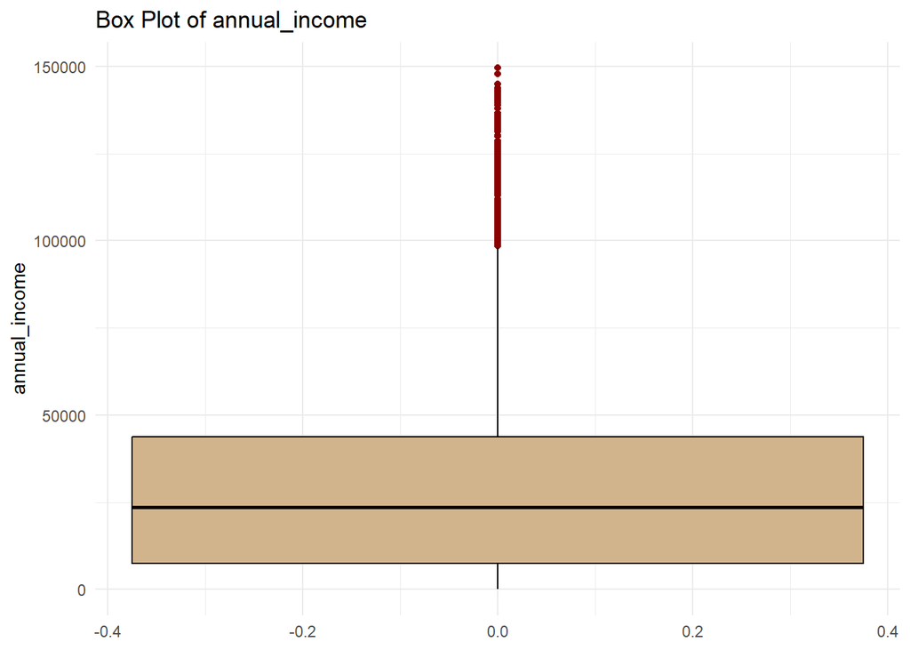

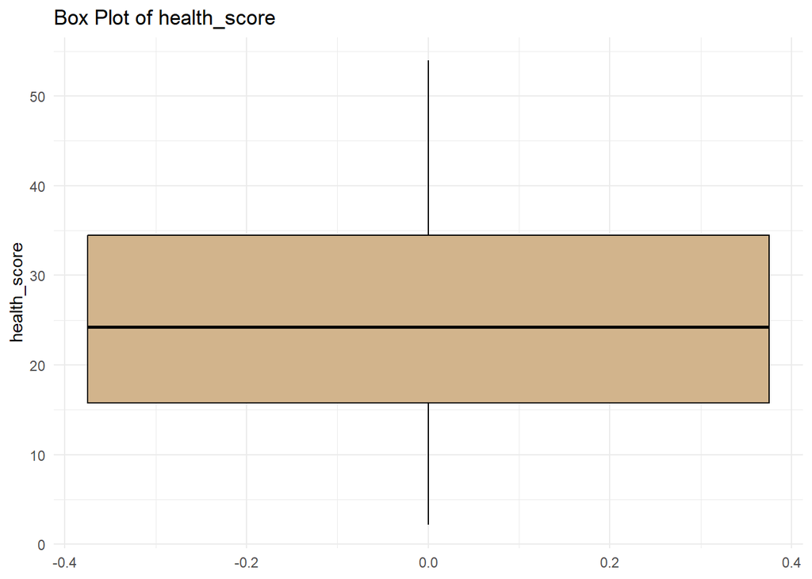

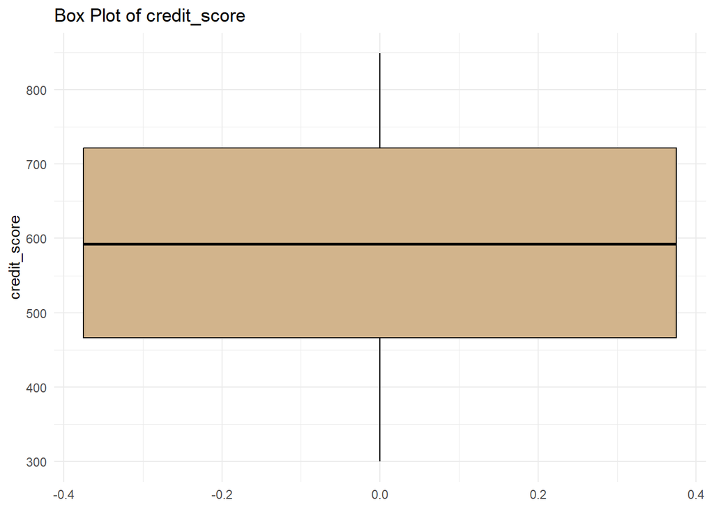

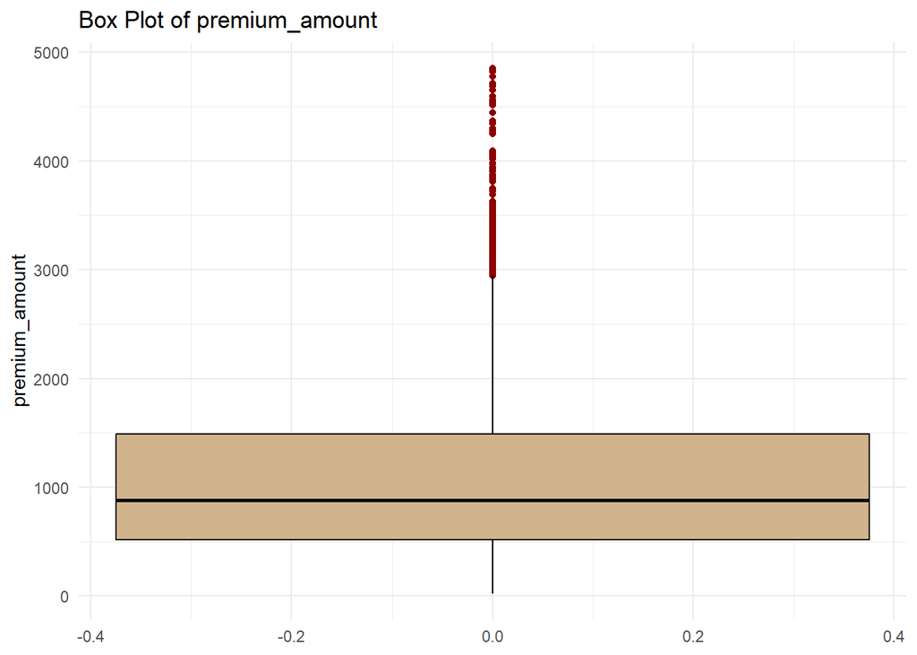

```r
continuous_boxplots <- lapply(continuous_vars, function(var) {
  ggplot(train, aes(y = !!sym(var))) +
    geom_boxplot(fill = "tan",
                 color = "black",
                 outlier.colour = "darkred") +
    theme_minimal() +
    labs(
      title = paste("Box Plot of", var)
    )
})

print(continuous_boxplots)
```

### Bar Plots of Nominal Variables

Afterwards, bar plots were generated to understand the frequency of the nominal variables in the data.

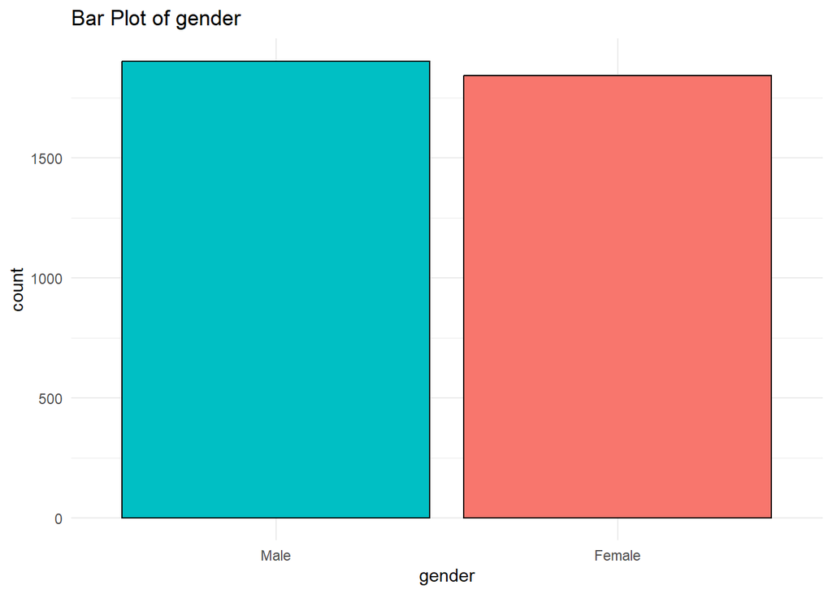

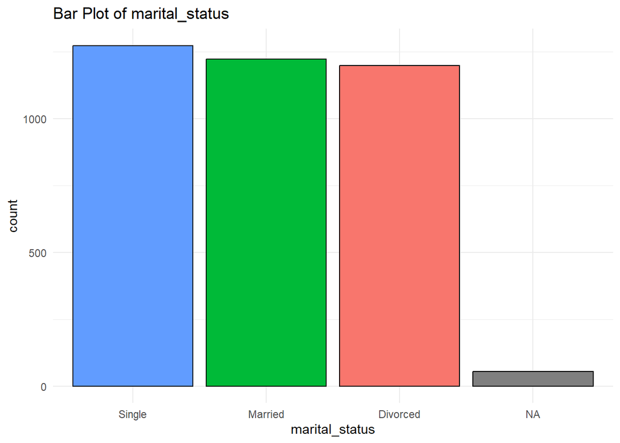

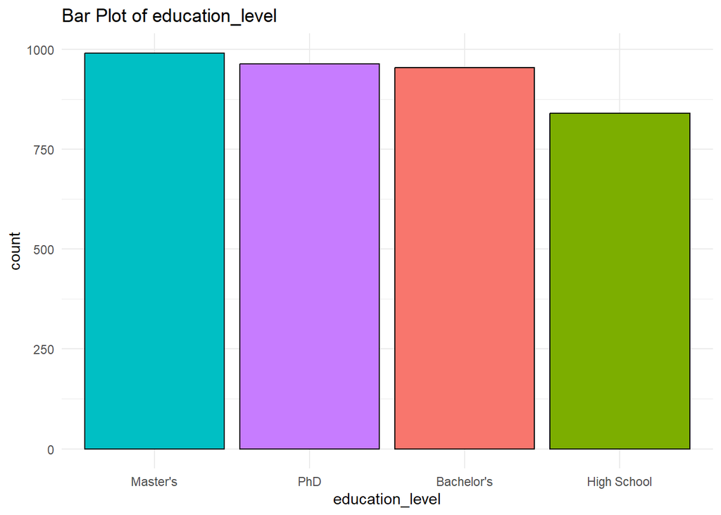

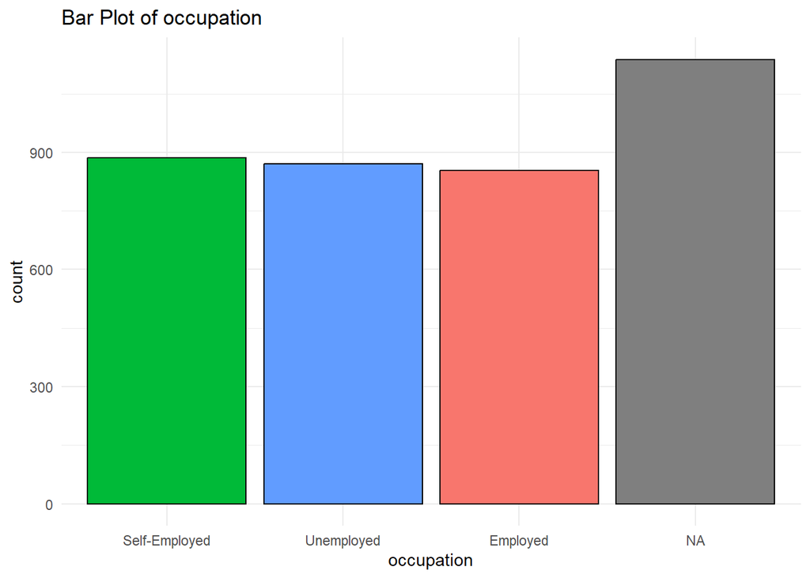

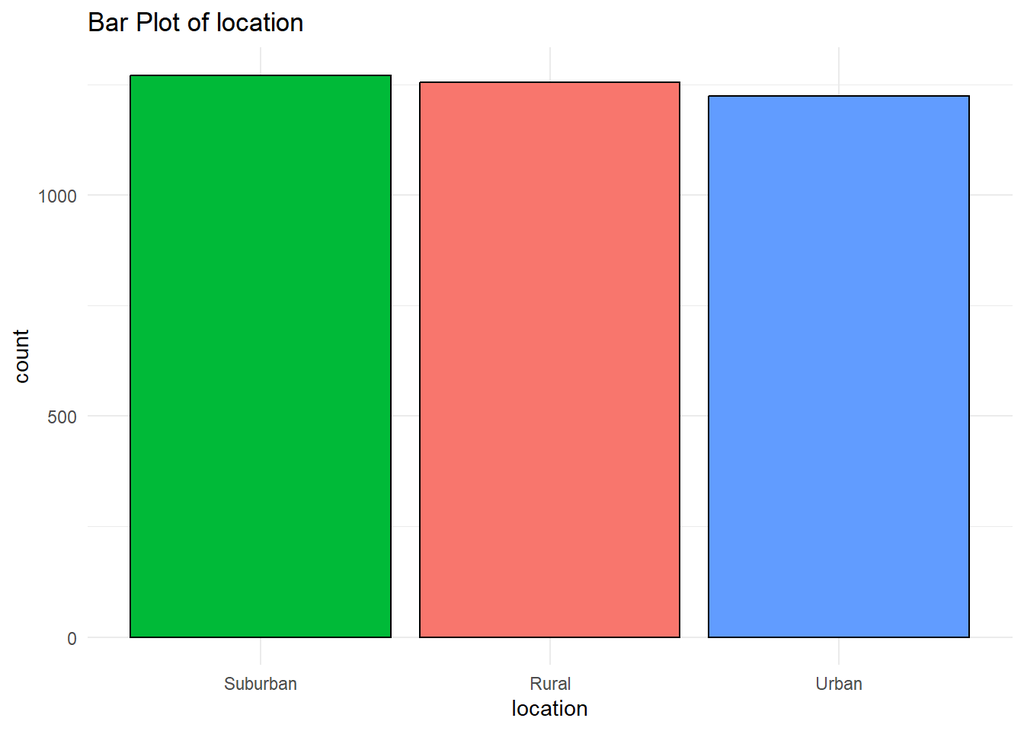

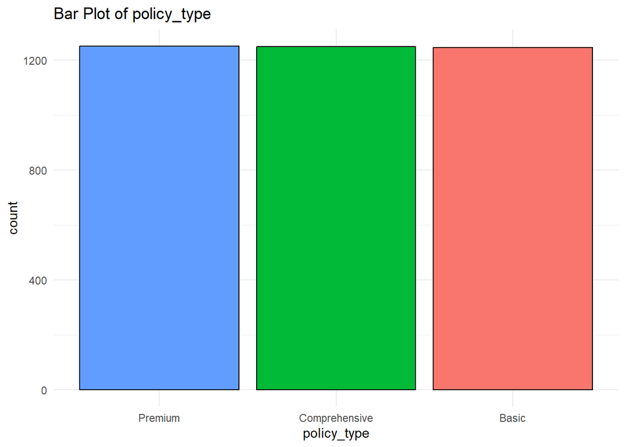

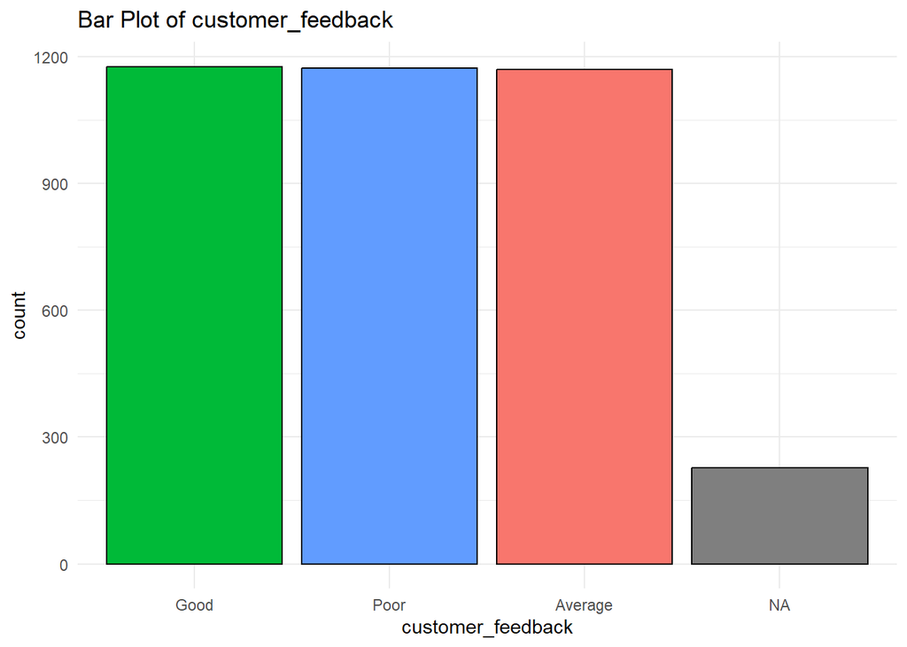

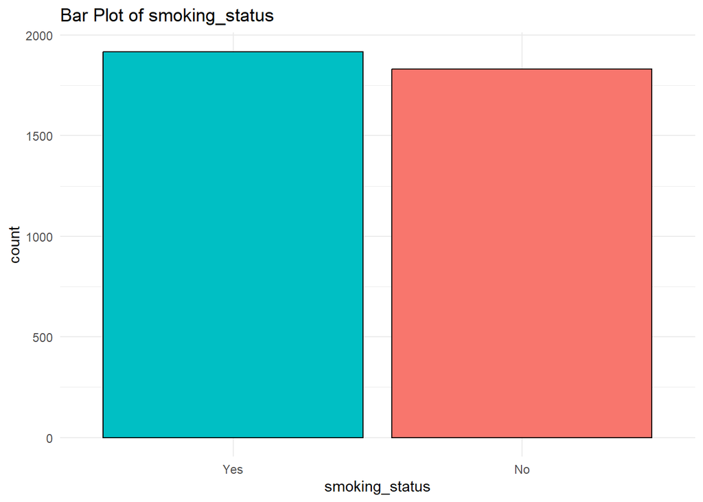

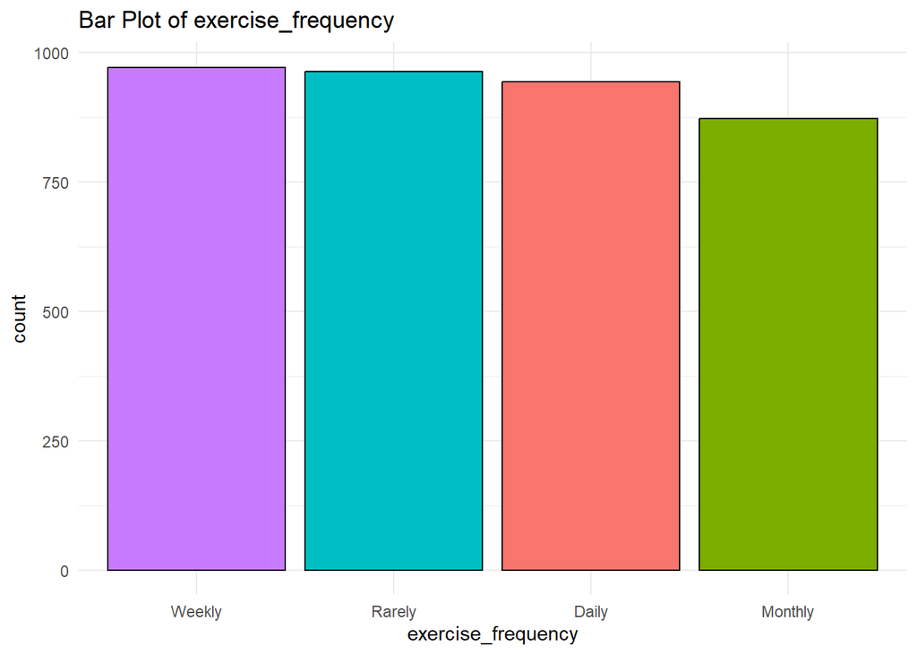

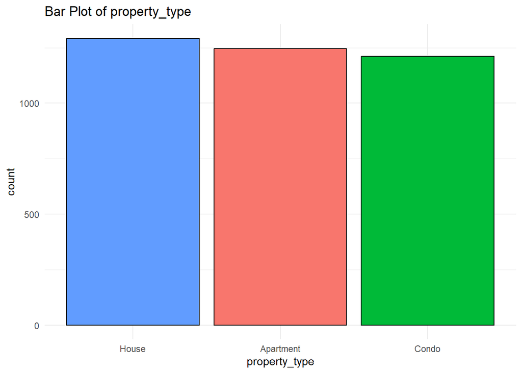

```r
nominal_vars <- c(
  "gender",
  "marital_status",
  "education_level",
  "occupation",
  "location",
  "policy_type",
  "customer_feedback",
  "smoking_status",
  "exercise_frequency",
  "property_type"
)

nominal_plots <- lapply(nominal_vars, function(var) {
  ggplot(train, aes(x = fct_infreq(!!sym(var)),
                    fill = !!sym(var))) +
    geom_bar(color = "black", show.legend = FALSE) +
    theme_minimal() +
    labs(
      title = paste("Bar Plot of", var),
      x = var
    )
})

print(nominal_plots)
```

### Bar Plots of Ordinal Variables

Bar plots were also used to understand the frequency of the ordinal variables in the dataset.

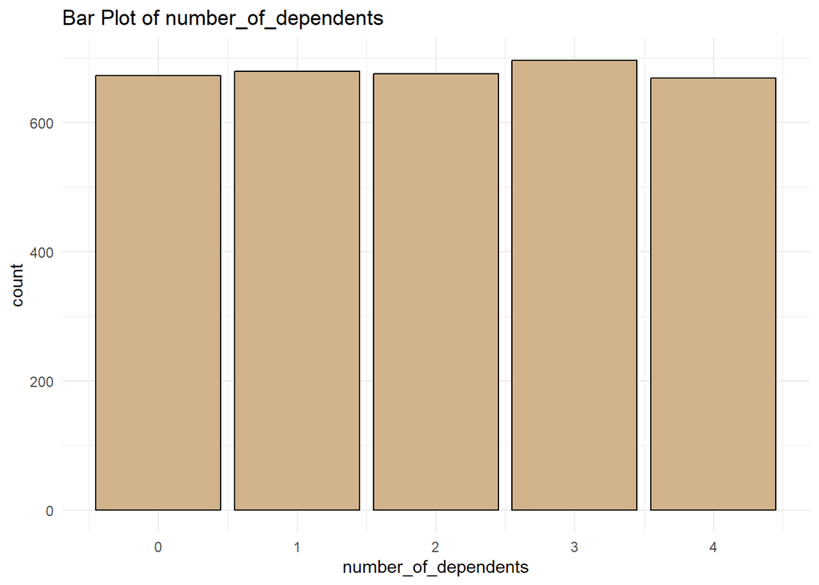

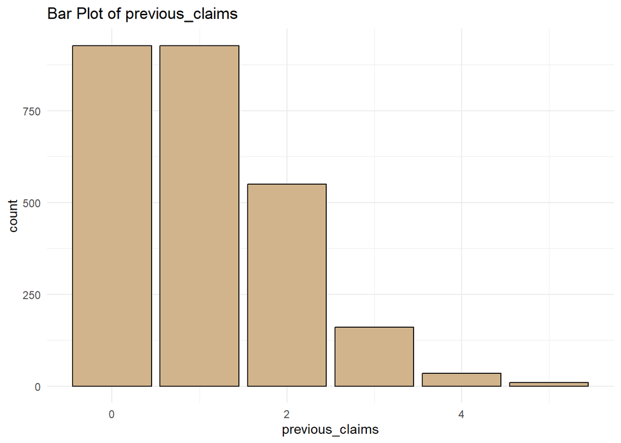

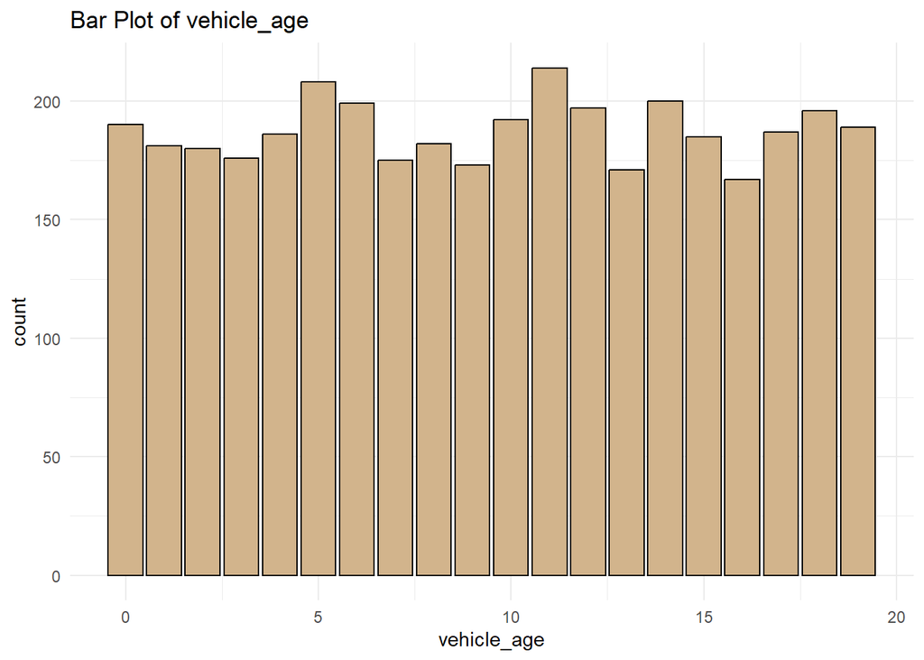

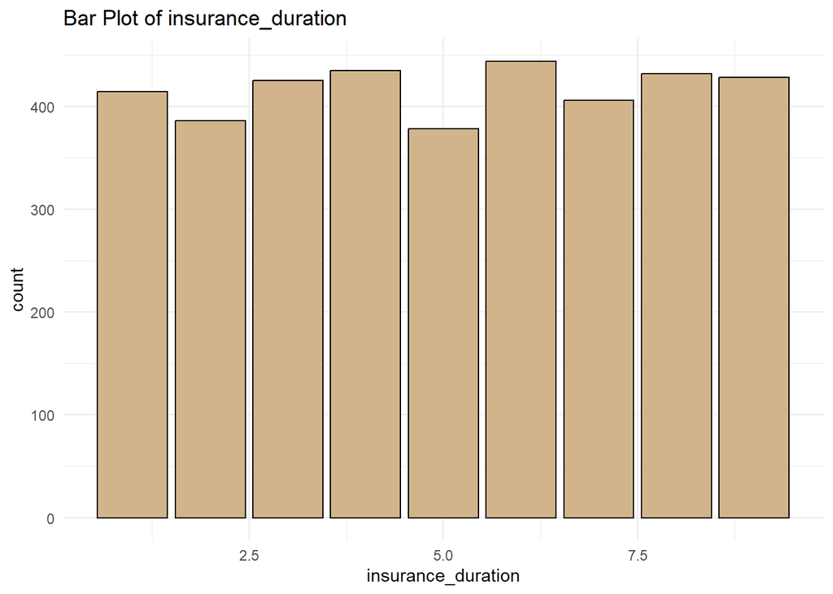

```r
ordinal_vars <- c(
"number_of_dependents",
"previous_claims",
"vehicle_age",
"insurance_duration"
)

ordinal_plots <- lapply(ordinal_vars, function(var) {
  ggplot(train, aes(x = !!sym(var))) +
    geom_bar(fill = "tan", color = "black") +
    theme_minimal() +
    labs(
      title = paste("Bar Plot of", var),
      x = var
    )
})

print(ordinal_plots)
```

# Data Preprocessing and Feature Engineering

## Creating `tidymodels` Recipes

To begin with, a `tidymodels` recipe was created to handle data preprocessing and feature engineering.

To handle missing continuous data, the median was imputed for all predictors. For nominal/ordinal predictors, the mode was imputed. Note: there were no missing data points in the target variable.

Afterwards, the numeric features were normalized using the `step_normalize` function. This ensured that all numeric features were centered (i.e., have a mean of zero and a standard deviation of 1) and placed all numeric features on the same scale. Normalization can be useful for a number of reasons:

- It can improve convergence in some ML models;
- It may help ensure that regularization techniques (e.g., L1, L2) are unbiased (i.e., do not unduly certain features due to range);
- It can facilitate the interpretation of features in models that produce coefficients

The nominal variables in the dataset were dummy-coded. This ensured that these variables were correctly structured for both tree-based and regression-based models.

Lastly, some tidying steps were incorporated into the recipe. This included

- removing features with near-zero variance or zero variance (see [here](https://recipes.tidymodels.org/reference/step_nzv.html) for details);
- removing the `id` and `policy_start_date` features, which cannot be used by any model

```r
data_recipe <- recipe(premium_amount ~., data = train) %>%
  step_date(policy_start_date, features = c("dow", "month", "year")) %>%
  step_impute_median(all_numeric_predictors()) %>%
  step_impute_mode(all_nominal_predictors()) %>%
  step_log(annual_income, base = 10) %>%
  step_normalize(all_numeric_predictors(), -policy_start_date_year) %>%
  step_dummy(all_nominal_predictors()) %>%
  step_nzv(all_predictors()) %>%
  step_rm(id, policy_start_date)
```

## Viewing `tidy` Data

The `recipe` was implemented using `prep` and `juice` in order to visually examine the data.

```r
prepped_recipe <- prep(data_recipe, training = train)
prepped_data <- juice(prepped_recipe)
datatable(head(prepped_data, 10))
```

|  | age | annual_income | number_of_dependents | health_score | previous_claims | vehicle_age | credit_score | insurance_duration | premium_amount | policy_start_date_year | gender_Male | marital_status_Married | marital_status_Single | education_level_High.School | education_level_Master.s | education_level_PhD | occupation_Self.Employed | occupation_Unemployed | location_Suburban | location_Urban | policy_type_Comprehensive | policy_type_Premium | customer_feedback_Good | customer_feedback_Poor | smoking_status_Yes | exercise_frequency_Monthly | exercise_frequency_Rarely | exercise_frequency_Weekly | property_type_Condo | … |
| --- | --- | --- | --- | --- | --- | --- | --- | --- | --- | --- | --- | --- | --- | --- | --- | --- | --- | --- | --- | --- | --- | --- | --- | --- | --- | --- | --- | --- | --- | --- |
| 1 | 1.548333697017305 | 0.9409228415661538 | -0.001789758742565019 | -1.078192749624304 | -1.23162231552966 | 0.0830070677211662 | -0.8598116644867881 | -1.177773311445518 | 270 | 2021 | 0 | 0 | 1 | 0 | 0 | 1 | 0 | 0 | 1 | 0 | 1 | 0 | 0 | 0 | 0 | 0 | 0 | 1 | 0 | … |
| 2 | 0.5131783711602362 | 0.8056151305726571 | 1.48888041173161 | 1.652908527598013 | -0.0285677315825228 | -1.482109985588157 | -1.446577426096479 | 1.530620114716688 | 500 | 2020 | 1 | 0 | 1 | 0 | 0 | 0 | 0 | 1 | 0 | 0 | 1 | 0 | 1 | 0 | 1 | 1 | 0 | 0 | 0 | … |
| 3 | -0.669856286962128 | 1.251879691986208 | 0.7435453264945225 | 0.812525026410028 | -0.0285677315825228 | -0.6126005115274221 | 0.8863466863275937 | 0.7567934215274861 | 171 | 2023 | 1 | 0 | 0 | 0 | 1 | 0 | 1 | 0 | 1 | 0 | 1 | 0 | 0 | 1 | 0 | 0 | 0 | 0 | 0 | … |
| 4 | 0.587118037292884 | 1.525459914409336 | -0.001789758742565019 | -1.361392261611956 | 1.174486852364615 | -0.9604043011517163 | -1.637453035294812 | -1.564686658040119 | 502 | 2020 | 1 | 0 | 1 | 1 | 0 | 0 | 1 | 0 | 0 | 1 | 1 | 0 | 1 | 0 | 1 | 0 | 0 | 1 | 0 | … |
| 5 | 1.252575032486714 | -0.1083134423821503 | 0.7435453264945225 | 0.04663309716552831 | -0.0285677315825228 | -1.134306195963863 | 1.169125366621421 | -0.4039466182563163 | 141 | 2024 | 1 | 0 | 1 | 0 | 0 | 1 | 1 | 0 | 0 | 1 | 0 | 0 | 0 | 0 | 1 | 0 | 1 | 0 | 1 | … |
| 6 | -0.8177356192274235 | 0.8725259347769262 | -0.001789758742565019 | -0.3651206246052708 | -0.0285677315825228 | -0.09089482709098087 | 0.1157747825269151 | -0.0170332716617155 | 268 | 2023 | 1 | 0 | 0 | 0 | 0 | 0 | 1 | 0 | 0 | 1 | 0 | 1 | 0 | 0 | 1 | 0 | 0 | 1 | 0 | … |
| 7 | 0.6610577034255317 | 0.8273157279635616 | -0.001789758742565019 | -0.06302706695495265 | -1.23162231552966 | 1.474222226218343 | -1.524341563177282 | -1.564686658040119 | 252 | 2020 | 0 | 0 | 0 | 0 | 0 | 0 | 0 | 1 | 0 | 1 | 0 | 1 | 0 | 0 | 1 | 0 | 1 | 0 | 1 | … |
| 8 | 1.474394030884657 | 0.4824422704063034 | -0.001789758742565019 | 0.2337859664789418 | -0.0285677315825228 | -1.482109985588157 | 0.7873741482247543 | 0.7567934215274861 | 310 | 2021 | 0 | 1 | 0 | 0 | 0 | 1 | 1 | 0 | 1 | 0 | 0 | 1 | 0 | 0 | 0 | 0 | 0 | 1 | 1 | … |
| 9 | 1.104695700221418 | 0.5275538210548606 | 1.48888041173161 | -0.7968745716767569 | -1.23162231552966 | -0.7865024063395691 | 1.239820036694878 | -1.564686658040119 | 339 | 2022 | 1 | 0 | 1 | 0 | 0 | 0 | 0 | 0 | 1 | 0 | 0 | 1 | 0 | 1 | 0 | 1 | 0 | 0 | 0 | … |
| 10 | -1.705011612819197 | 0.3000110993422619 | 0.7435453264945225 | -0.4349340976935995 | -0.0285677315825228 | 0.7786146469697545 | 0.2571641226738286 | 0.3698800749328853 | 23 | 2021 | 1 | 0 | 1 | 0 | 0 | 0 | 0 | 0 | 1 | 0 | 0 | 0 | 0 | 0 | 0 | 0 | 0 | 1 | 0 | … |

# Model Training

In this project, three different models were trained and evaluated to determine which model would predict `premium_amount` most accurately. Below, I have provided a brief summary of these models.

The first model, an elastic net regression, is a linear regression technique that incorporates L1 (lasso) and L2 (ridge) penalties to regularize a regression model. The integration of these penalties results in a model that is more robust to overfitting and multicollinearity issues.

The second model, a random forest model, is a non-parametric tree-based machine learning algorithm. Through bootstrapping and the analysis of data via multiple decision trees, random forest models produce a large number of predictions before aggregating these into a final prediction. Random forest models have several key advantages, including their ability to handle high-dimensional data (i.e., datasets with large numbers of potentially collinear features) and capture interactions and non-linear relationships.

The final model, an eXtreme Gradient Boosting model (XGBoost), is another non-parametric tree-based model. Like random forest models, XGBoost models are considered *ensemble* models, as both techniques utilize multiple models to generate final predictions. While random forest models involve the parallel construction of decision trees, however, XGBoost models involve the sequential construction of decision trees. Specifically, XGBoost models use a process known as *gradient boosting*, wherein a series of models are built one at a time, with each new model correcting the errors of the previous one. XGBoost models are known to be highly efficient and are generally robust to overfitting. As with random forest models, they are also capable of effectively (and “automatically”) capturing feature interactions and non-linear feature-target relationships.

## Specifying Models

The first step in the `tidymodels` workflow involves specifying the models that will be used. Specifically, I indicated (a) what hyperparameters would be used, (b) what the underlying “engine” would be (i.e., the package being used for the model), and (c) the type of problem being solved (i.e., regression vs. classification).

```r
elastic_net_spec <- linear_reg(
  penalty = tune(),
  mixture = tune()
) %>%
  set_engine("glmnet") %>%
  set_mode("regression")

rf_spec <- rand_forest(
  mtry = tune(),
  trees = tune(), # default
  min_n = tune()
) %>%
  set_engine("ranger") %>%
  set_mode("regression")

xgb_spec <- boost_tree(
  trees = tune(),
  mtry = tune(),
  tree_depth = tune(),
  min_n = tune(),
  sample_size = tune(),
  loss_reduction = tune(),
  learn_rate = tune()
) %>%
  set_engine("xgboost",
             eval_metric = "mae") %>%
  set_mode("regression")
```

## Creating Workflow Set

To create a series of workflows, `workflow_set()` was used to combine the initial recipe with each model specification.

```r
workflow_set <- workflow_set(
  preproc = list(recipe = data_recipe),
  models = list(
    elastic = elastic_net_spec,
    rf = rf_spec,
    xgb = xgb_spec
  )
)
```

## Setting Up Cross-Validation

5-fold cross-validation was used to train the three models. This is a technique that involves splitting the training data into *n* partitions. Each model is trained on *n* - 1 of the partitions and tested on the unused partition. This process is repeated such that each partition is used once for testing. Afterwards, the performance metrics for each model (i.e., those obtained from the testing data) are averaged to produce an aggregate estimate of performance. Cross-validation helps to reduce overfitting by providing multiple train-test splits during the training process and also provides a space for hyperparameter tuning.

```r
set.seed(123)

cv_folds <- vfold_cv(train, v = 5, strata = premium_amount) # init. folds for 5-fold cross-validation
```

## Fitting Workflow

Parallel processing was used to increase the speed of the training process. The `workflow_map` function was used to map the previously defined workflow (i.e., preprocessing, training, hyperparameter tuning) of the three models. Given the computational limits of my personal computer, I used the “tune_race_anova” option for hyperparameter tuning. This is a more efficient grid searching method than a semi-random or fully random search, and produces relatively similar performances. Given the outliers and right-skewness of the distribution of our target variable, the MAE metric was selected to assess performance and guide the tuning process.

```r
set.seed(123)

cores <- parallel::detectCores(logical = TRUE) - 1

cl <- makeCluster(cores)
registerDoParallel(cl)

results <- workflow_map(
  workflow_set,
  "tune_race_anova", # racing with repeated-measures ANOVA
  resamples = cv_folds,
  grid = 30, # semi-random grid
  metrics = metric_set(mae, rsq),
  control = control_race(save_pred = TRUE, parallel_over = "everything")
)
```

```
i Creating pre-processing data to finalize unknown parameter: mtry
i Creating pre-processing data to finalize unknown parameter: mtry
```

```r
stopCluster(cl)
```

## Compare Metrics

The performance metrics of the “best-performing” (defined by MAE) of each of the three types of models were plotted and compared. The best-performing (i.e., XGBoost) model was selected and saved.

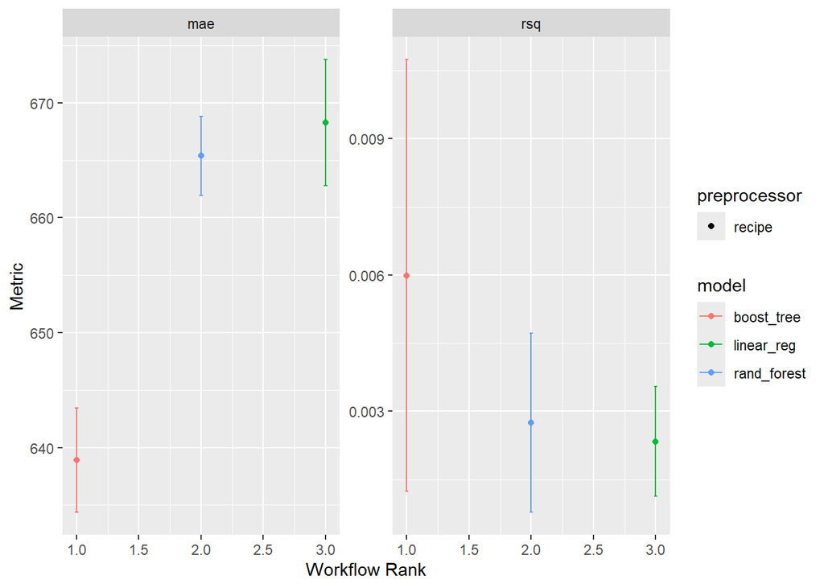

```r
autoplot(results,
         select_best = TRUE) # Visualization of performance metrics
```

```r
rank_results(results,
             rank_metric = "mae",
             select_best = TRUE)
```

```
# A tibble: 6 × 9
  wflow_id       .config  .metric    mean std_err     n preprocessor model  rank
  <chr>          <chr>    <chr>     <dbl>   <dbl> <int> <chr>        <chr> <int>
1 recipe_xgb     Preproc… mae     6.39e+2 2.76e+0     5 recipe       boos…     1
2 recipe_xgb     Preproc… rsq     5.99e-3 2.89e-3     5 recipe       boos…     1
3 recipe_rf      Preproc… mae     6.65e+2 2.10e+0     5 recipe       rand…     2
4 recipe_rf      Preproc… rsq     2.74e-3 1.20e-3     5 recipe       rand…     2
5 recipe_elastic Preproc… mae     6.68e+2 3.34e+0     5 recipe       line…     3
6 recipe_elastic Preproc… rsq     2.33e-3 7.34e-4     5 recipe       line…     3
```

```r
best_results <-
  results %>%
  extract_workflow_set_result("recipe_xgb") %>%
  select_best(metric = "mae")

best_results
```

```
# A tibble: 1 × 8
   mtry trees min_n tree_depth learn_rate loss_reduction sample_size .config
  <int> <int> <int>      <int>      <dbl>          <dbl>       <dbl> <chr>
1    23  1755    22          4    0.00116           10.4       0.268 Preprocess…
```

# Final Model Evaluation

## Testing the Model

I extracted the workflow from model training and used `last_fit()` to train and test an XGBoost model with the previously defined hyperparameters.

```r
xgb_test_results <-
  results %>%
  extract_workflow("recipe_xgb") %>%
  finalize_workflow(best_results) %>%
  last_fit(split = data_split,
           metrics = metric_set(mae, rsq))

collect_metrics(xgb_test_results)
```

```
# A tibble: 2 × 4
  .metric .estimator .estimate .config
  <chr>   <chr>          <dbl> <chr>
1 mae     standard   634.      Preprocessor1_Model1
2 rsq     standard     0.00187 Preprocessor1_Model1
```

## Feature Importance

Lastly, I used the `DALEXtra` package to conduct permutation-based variable importance analyses. This is a “model-agnostic” method for evaluating the predictive value of features in a model. In other words, this method does not rely on the assumptions or form of any given model and can thus be used across a variety of models.

```r
fitted_workflow <- extract_fit_parsnip(xgb_test_results)

explainer <- explain_tidymodels(
  model = fitted_workflow,
  data = prepped_data %>%
    select(-premium_amount),
  y = prepped_data$premium_amount,
  label = "XGBoost Model"
)
```

```
Preparation of a new explainer is initiated
  -> model label       :  XGBoost Model
  -> data              :  3748  rows  46  cols
  -> data              :  tibble converted into a data.frame
  -> target variable   :  3748  values
  -> predict function  :  yhat.model_fit  will be used (  default  )
  -> predicted values  :  No value for predict function target column. (  default  )
  -> model_info        :  package parsnip , ver. 1.2.1 , task regression (  default  )
  -> predicted values  :  numerical, min =  728.7689 , mean =  951.7585 , max =  1230.407
  -> residual function :  difference between y and yhat (  default  )
  -> residuals         :  numerical, min =  -1096.18 , mean =  148.2213 , max =  3877.724
  A new explainer has been created!
```

```r
loss_mae <- function(observed, predicted) {
  mean(abs(observed - predicted))
}

attr(loss_mae, "loss_name") <- "Mean Absolute Error (MAE)"

feature_importance <- model_parts(
  explainer,
  loss_function = loss_mae,
  type = "difference",
  N = NULL)

feature_importance
```

```
                      variable mean_dropout_loss         label
1                 _full_model_        0.00000000 XGBoost Model
2  policy_start_date_month_Apr        0.01200763 XGBoost Model
3  policy_start_date_month_Jun        0.03218099 XGBoost Model
4  policy_start_date_month_Dec        0.05149359 XGBoost Model
5  policy_start_date_month_Mar        0.06852035 XGBoost Model
6  policy_start_date_month_Sep        0.07472190 XGBoost Model
7  policy_start_date_month_May        0.07511839 XGBoost Model
8  policy_start_date_month_Feb        0.07530172 XGBoost Model
9  policy_start_date_month_Nov        0.07868920 XGBoost Model
10   policy_start_date_dow_Sat        0.08006668 XGBoost Model
11   policy_start_date_dow_Fri        0.08736567 XGBoost Model
12   policy_start_date_dow_Tue        0.10948380 XGBoost Model
13 policy_start_date_month_Aug        0.12254479 XGBoost Model
14 policy_start_date_month_Oct        0.12685714 XGBoost Model
```

[output cut: 34 more lines]

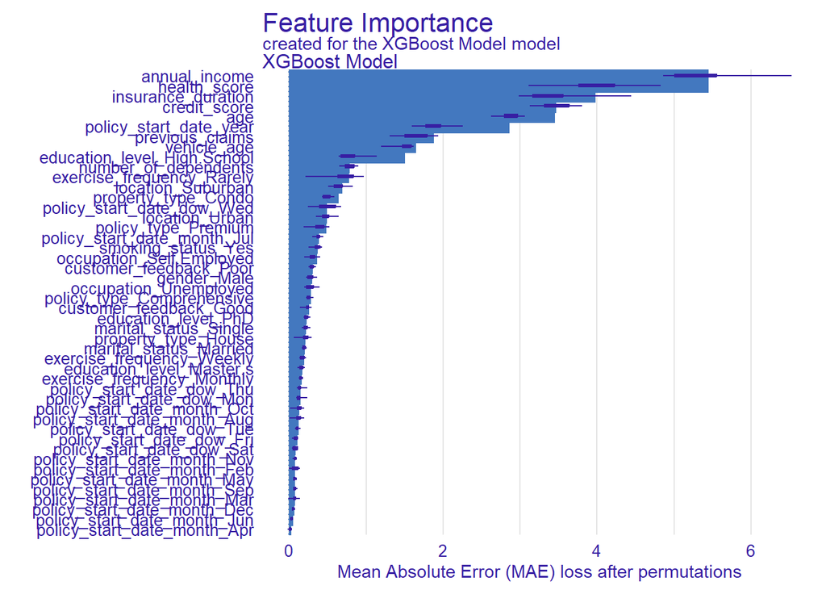

```r
plot(feature_importance)
```

## Residual Exploration

Afterwards, I created a scatterplot of the observed vs. predicted values for `premium_amount` to visualize the predictive performance of the model. In addition, I used `DALEX` and `DALEXtra` functions to examine the distribution of the residuals.

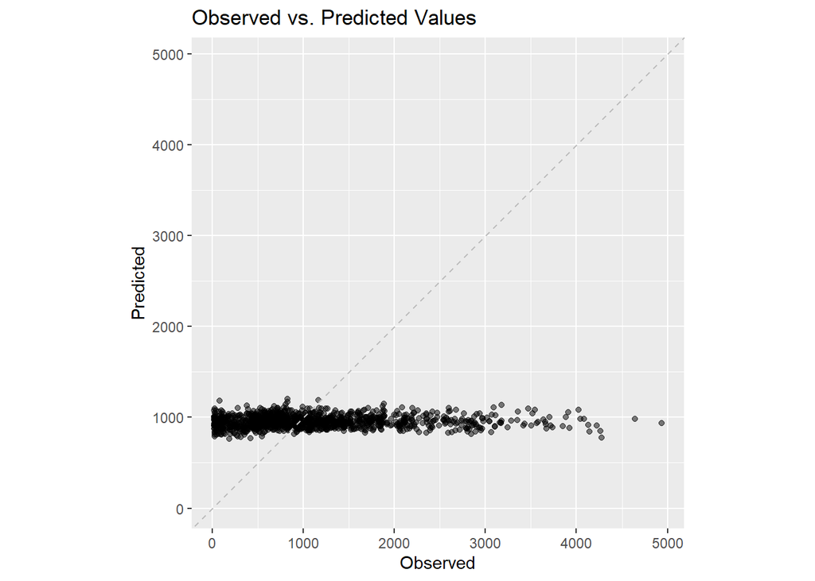

```r
xgb_test_results %>%
  collect_predictions %>%
  ggplot(aes(x = premium_amount, y = .pred)) +
  geom_point(alpha = 0.5) +
  geom_abline(color = "grey", lty = 2) +
  coord_obs_pred() +
  labs(
    title = "Observed vs. Predicted Values",
    x = "Observed",
    y = "Predicted"
  )
```

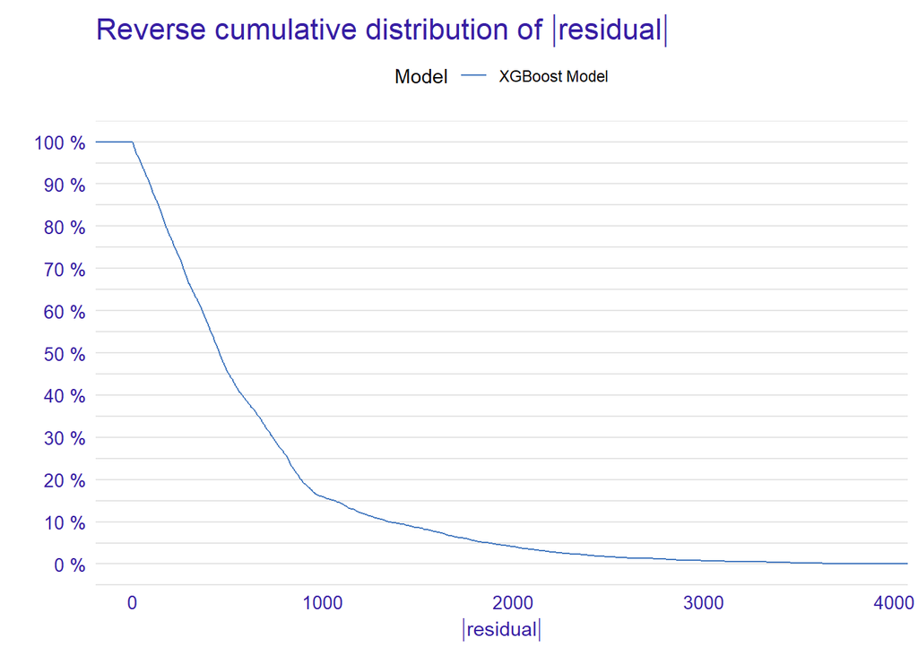

```r
residuals <- model_performance(explainer)

plot(residuals)
```

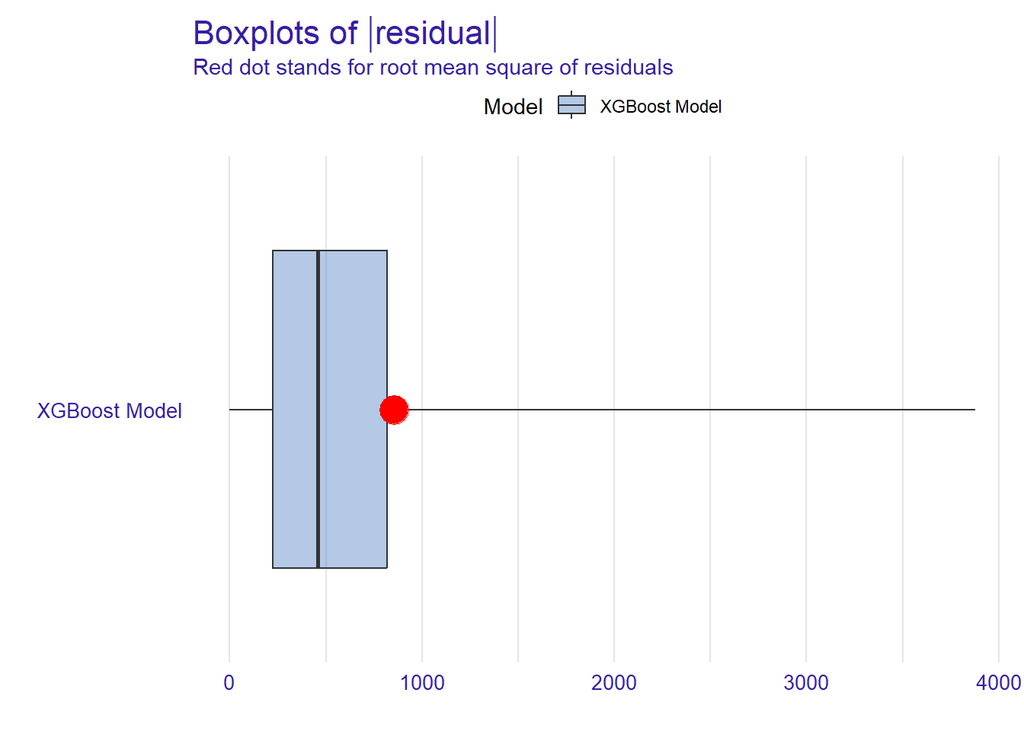

```r
plot(residuals, geom = "boxplot")
```